# Part II - Prosper Loan Data - Explanation.

## by Kolawole Joseph. E

## Investigation Overview

The overall goals of this presentation is to present the derived insights from the dataset. For instance: about the loan repayment defaulters, conditions that affects loan repayment like Employment status, of borrowers, Loan term, Borrower Rate, as well as some other trends in the dataset. And apparently, the LoanStatus, CurrentDelinquencies, AmountDelinquent, DelinquenciesLast7Years, LoanCurrentDaysDelinquent, LoanOriginalAmount, as well as other features will help in this investigative work.

Hence, it will be worthwhile to note that the number of investment from friends is a driving force behind the number of recommendations for loans. Both InvestmentFromFriendsCount and Recommendations are positively correlated, hence as more friends invest, the Recommendation count increases. Though this seem to be densely populated only at the origin between the count of 0 to 10 for. This leaves a question in mind if this is a manipulation from the borrower to quickly get loan from Prosper or a somewhat means to get recommendations and investments.

Inconclusion, More loans are given to Borrowers whose income are verifiable. And borrowers whose income are verifiable are major defaulters in loan repayment.

## Dataset Overview

The Prosper Loan dataset has 113,937 entries with 81 features. Most variables are numeric in nature, 18 of which are Categorical , 60 are Numerical while 3 are Booleans.

The main feature of interest in the dataset is to derive insights from the dataset. And apparently, the LoanStatus, CurrentDelinquencies, AmountDelinquent, DelinquenciesLast7Years, LoanCurrentDaysDelinquent, LoanOriginalAmount, as well as other features will help in this investigative work.

### **Check the number of Investment from friends and compare it with recommendations to see if it really determines its number of recommendations.**

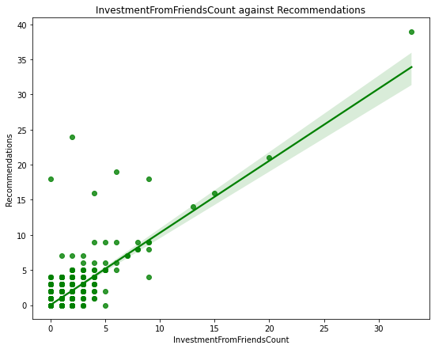

```python
# Plot a regplot to check the relationship between InvestmentFromFriendsCount and Recommendations
fig, ax = plt.subplots(figsize=(9, 7))
sns.regplot(x = 'InvestmentFromFriendsCount', y = 'Recommendations',  data = df_loan, color = 'green').set(title = 'InvestmentFromFriendsCount against Recommendations');
```

Obviously, the number of investment from friends is a driving force behind the number of recommendations for loans. Both InvestmentFromFriendsCount and Recommendations are positively correlated, hence as more friends invest, the Recommendation count increases. Though this seem to be densely populated only at the origin between the count of 0 to 10 for. This leaves a question in mind if this is a maipulation from the borrower to quickly get loan from Prosper or a somewhat means to get recomendations and investments

**Loan original amount determines the loan monthly payment.**

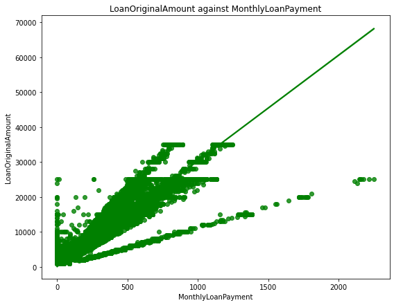

```python
# plot a regplot to check the relationship between MonthlyLoanPayment and LoanOriginalAmount
fig, ax = plt.subplots(figsize=(9, 7))
sns.regplot(x = 'MonthlyLoanPayment', y = 'LoanOriginalAmount',  data = df_loan, color = 'green').set(title = 'LoanOriginalAmount against MonthlyLoanPayment');
```

Ofcourse, the Loan original amount determines it's monthly payment amount. As the Original loan amount increases, the monthly payment amount increases

**The longer the term, the higher the loan amount and vice versa. And somewhat delinquencies**

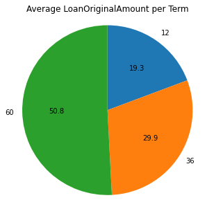

```python
# Pie chart for Term vs LoanOriginalAmount mean
fig, ax = plt.subplots(figsize=(5, 5))
plt.pie(x = df_loan.groupby('Term').LoanOriginalAmount.mean(),
        labels = df_loan.groupby('Term').LoanOriginalAmount.mean().index, colors = None,
        startangle = 90,
        counterclock = False, autopct='%0.1f')
plt.axis('square')
plt.title('Average LoanOriginalAmount per Term');
```

As shown above, 12 which is the shortest loan term has the lowest average loan amount. This is followed by 36 and finally 60 (the longest loan term) with the highest average loan amount.

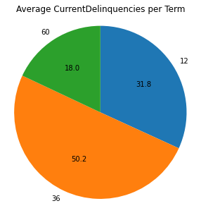

```python
# Pie chart for Term vs CurrentDelinquencies mean
fig, ax = plt.subplots(figsize=(5, 5))
plt.pie(x = df_loan.groupby('Term').CurrentDelinquencies.mean(),
        labels = df_loan.groupby('Term').CurrentDelinquencies.mean().index, colors = None,
        startangle = 90,
        counterclock = False, autopct='%0.1f')
plt.axis('square')
plt.title('Average CurrentDelinquencies per Term');
```

**Higher ProsperRating is associated with lower BorrowerAPR and vice versa.**

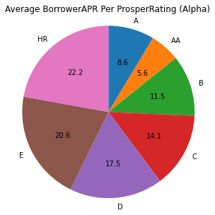

```python
# Pie chart for ProsperRating (Alpha) vs BorrowerAPR mean
fig, ax = plt.subplots(figsize=(5, 5))
plt.pie(x = df_loan.groupby('ProsperRating (Alpha)').BorrowerAPR.mean(),
        labels = df_loan.groupby('ProsperRating (Alpha)').BorrowerAPR.mean().index, colors = None,
        startangle = 90,
        counterclock = False, autopct='%0.1f')
plt.axis('square')
plt.title('Average BorrowerAPR Per ProsperRating (Alpha)');
```

**More loans are given to Borrowers whose income are verifiable.**

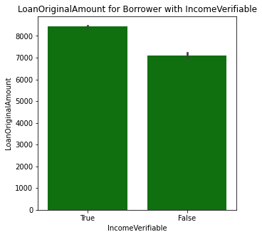

```python
# visualize the LoanOriginalAmount for each IncomeVerifiable Borrower
fig, ax = plt.subplots(figsize=(5, 5))
ax = sns.barplot(x = df_loan['IncomeVerifiable'], y = df_loan['LoanOriginalAmount'], color = 'green', order = df_loan['IncomeVerifiable'].value_counts(ascending = False).index)

plt.title('LoanOriginalAmount for Borrower with IncomeVerifiable');
plt.xlabel('IncomeVerifiable');
plt.ylabel('LoanOriginalAmount');
```

**Borrowers whose income are verifiable are major defaulters in loan repayment**

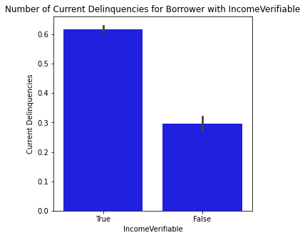

```python
# visualize the CurrentDelinquencies for IncomeVerifiable
fig, ax = plt.subplots(figsize=(5, 5))
sns.barplot(x = df_loan['IncomeVerifiable'], y = df_loan['CurrentDelinquencies'], color = 'b', order = df_loan['IncomeVerifiable'].value_counts(ascending = False).index).set(title = 'Current Delinquencies Per Borrower State');

plt.title('Number of Current Delinquencies for Borrower with IncomeVerifiable');
plt.xlabel('IncomeVerifiable');
plt.ylabel('Current Delinquencies');
```

Higher percent (>50%) of CurrentDelinquencies are from borrowers with IncomeVerifiable.